# Project 3. Functional Genomics Analysis for Gene Expression Arrays

## The Outline for Project 3

In this project, we will perform classical functional genomic analysis on a gene expression microarray dataset. We will first conduct hierarchical clustering on samples, and then determine the proper feature selection method that can improve the prediction of the tissue labeling. Next, we will perform clustering on genes, during which we will determine the number of gene modules using the silhouette analysis, followed by interpreting the gene clusters by gene set enrichment analysis in DAVID.

## 1. Construct SummarizedExperiment Object using Expression Matrix and Experimental Design

The data set containing the expression levels obtained from a set of microarray experiments is stored in a matrix; while the rows of the matrix are genes / probes, and the columns of the matrix are samples. The expression matrix is saved in a tabular file named `expression.csv` under the project 3 directory. Please use the function `read.csv ()` to load the CSV file into R. Remember to set the parameter `row.names =" probeID "` so that the first column becomes the row name of the imported data.frame object.

Then, we need to read in another important file called `tissue.csv`. This file is a table with rows corresponding to the tissue information of each sample. Please read the file into R with `read.csv()`.

Next, store the expression matrix and the tissue information into a single `summarizedExperiment` object named by `SE`. The expression matrix should be entered in the `assays=` argument, and the tissue information should be entered in the `colData=` argument.

Also, please notice that the `colData` slot in the summarizedExperiment object must be a `DataFrame` object (not `data.frame`), so make sure to convert the tissue into DataFrame with the function `DataFrame()`.

The reason we want to construct a `summarizedExperiment` object is to tidy things up. Compared to simultaneously managing multiple variables (expression assays, column designs, row’s metadata, and row’s GRanges), it is much easier to code with only one variable that includes all of the data in a genomic experiment.

```r
## === Hint code, fill the "___"  ============= ##
#tissue <- read.csv(___)
#e <- read.csv(___, row.names = "probeID")
#library(SummarizedExperiment)
#SE <- SummarizedExperiment(assays = ___, colData = DataFrame(___)) #Represent the data into a summarizedExperiment
## ===== Enter your code below  =============== ##
tissue <- read.csv("tissue.csv")
e <- read.csv("expression.csv", row.names = "probeID")
library(SummarizedExperiment)
SE <- SummarizedExperiment(assays = e, colData = DataFrame(tissue)) #Represent the data into a summarizedExperiment
```

Examine the summarizedExperiment object as the following:

```r
SE
```

```
## class: SummarizedExperiment
## dim: 22215 189
## metadata(0):
## assays(1): ''
## rownames(22215): 1007_s_at 1053_at ... 91920_at 91952_at
## rowData names(0):
## colnames(189): GSM11805.CEL.gz GSM11814.CEL.gz ... GSM307640.CEL.gz
##   GSM307641.CEL.gz
## colData names(1): Tissue
```

```r
table(SE$Tissue)
```

```
##
##  cerebellum       colon endometrium hippocampus      kidney       liver
##          38          34          15          31          39          26
##    placenta
##           6
```

- SAQ1: How many genes or probes are included in this set of the experiments? How many samples are there? How many unique tissues are there? What are the contents of `rownames` and `colnames` of the SummarizedExperiment object?
- Answer: 22215 genes; 189 samples; 7 tissues; colnames are sample names; rownames are feature names or gene names.

## 2. Hierarchical Clustering by Samples

Next, we will perform hierarchical clustering through the columns of the expression array. As introduced in lecture 8, to perform hierarchical clustering, we must calculate the distance metric between the objects in advance.

The distance metric can be calculated in R using the function `dist()`. Please note that by default, `dist()` is used to calculate the distances between rows of the matrix input. Therefore, if you want to cluster by columns, you need to to use the function `t()` to transform the row and columns of the matrix.

Then, you can then use the `hclust()` function to build a hierarchical clustering dendrogram with distance metrics. In this problem, please perform a hierarchical clustering on Euclidean distance between the columns of the expression assay, and store the result `hclust` object in the variable `hc`.

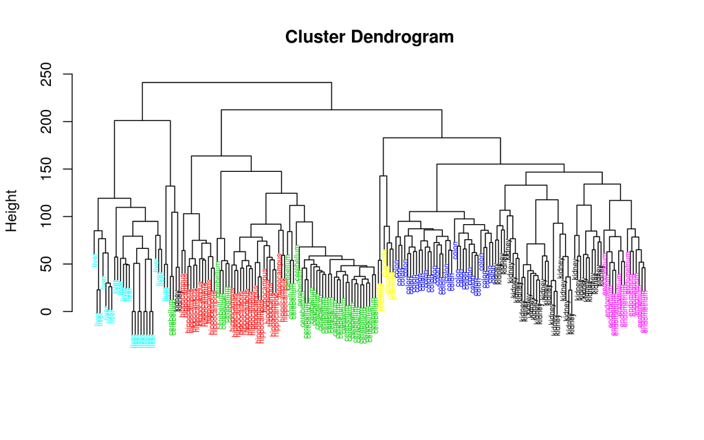

```r
## === Hint code, fill the "___"  ============= ##
#d <- dist( t(___) ) #Use assay() to extract the expression matrix in SE
#hc <- hclust(___)
## ===== Enter your code below  =============== ##
d <- dist( t(assay(SE)) ) #Use assay() to extract the expression matrix in SE
hc <- hclust(d)
## ===== Your code is finished  =============== ##
library(rafalib)
myplclust(hc, labels=SE$Tissue, lab.col=as.fumeric(as.character(SE$Tissue)),cex=0.5)
```

After drawing the dendrogram, you should able to see a tree structure representing the arrangement of sample clusters. We could observe that the division of the branches has a significant correlation with the tissue label.

Next, we will retrieve the “partition” based on the hierachical clustering dendrogram. To achieve this, we need to apply the function `cutree()`. Set the number of clusters (also called cardinality or K) to the number of tissues.

Then, tabulate the two factors of cluster partition and the true tissue labeling. Display the contingency table. Use `chisq.test()` to evaluate the contingency table.

Then, use `DescTools::MutInf()` to calculate the empirical mutual information between the 2 factors.

[Mutual information](https://en.wikipedia.org/wiki/Mutual_information) is a measure of the dependence between two random variables. If the 2 variables are independent, their mutual information will be 0. MI is defined as the information gain when modeling the dependency between the 2 random variables (compared with the independence modeling).

```r
## === Hint code, fill the "___"  ============= ##
#hclusters <- cutree(___, k=__)
#tb <- table(true = ___, cluster = ___)
#tb
#chisq.test(tb)
#DescTools::MutInf(___, ___)
## ===== Enter your code below  =============== ##
hclusters <- cutree(hc, k=7)
tb <- table(true = SE$Tissue, cluster = hclusters)
tb
```

```
##              cluster
## true           1  2  3  4  5  6  7
##   cerebellum   0  0 36  0  0  2  0
##   colon        0  0  0 34  0  0  0
##   endometrium 15  0  0  0  0  0  0
##   hippocampus  0 12 19  0  0  0  0
##   kidney      37  0  0  0  0  2  0
##   liver        0  0  0  0 24  2  0
##   placenta     0  0  0  0  0  0  6
```

```r
chisq.test(tb)
```

```
##
##  Pearson's Chi-squared test
##
## data:  tb
## X-squared = 787.33, df = 36, p-value < 2.2e-16
```

```r
DescTools::MutInf(SE$Tissue, hclusters)
```

```
## [1] 2.090514
```

- SAQ2: What are the calculated Chi-square statistics and mutual information? Are the cluster partitions significantly associate with the tissue labels? Is the prediction of the tissues perfect? Please explain your reasons.
- Answer: In Chi-square: p-value < 2.2e-16. MI = 2.090514. Yes, they are sigificantly associated. It is good because MI is more than 0, but not perfect. From the table of true cluster and predicted cluster, some tissues are clustered in more than one groups.

Change the clustering method to “ward.D2” by setting the `method` parameter of the `hclust()` function. Repeat the above analysis to see if the mutual information between the prediction and the label has increased.

```r
## === Hint code, fill the "___"  ============= ##
#hc <- hclust(___, method = ___)
#hclusters <- cutree(___, k=__)
#tb <- table(true = ___, cluster = ___)
#tb
#DescTools::MutInf(___, ___)
## ===== Enter your code below  =============== ##
hc <- hclust(d, method = "ward.D2")
hclusters <- cutree(hc, k=7)
tb <- table(true = SE$Tissue, cluster = hclusters)
tb
```

```
##              cluster
## true           1  2  3  4  5  6  7
##   cerebellum   0  5 31  0  0  2  0
##   colon        0  0  0 34  0  0  0
##   endometrium 15  0  0  0  0  0  0
##   hippocampus  0 31  0  0  0  0  0
##   kidney      37  0  0  0  0  2  0
##   liver        0  0  0  0 24  2  0
##   placenta     0  0  0  0  0  0  6
```

```r
DescTools::MutInf(SE$Tissue,hclusters)
```

```
## [1] 2.250404
```

## 3. Feature Selection and Heat Map

Then, we will use a simple but most widely applied feature extraction technique: keeping only the genes that have the highest variance. This time, we will keep the 85 rows with the highest (row) variances.

You could use the function `rowVar()` defined in the `geneFilter` package to calculate the variance of the gene. Save the index of the selected rows into a variable named `idx`. Using the ward.D2 method, conduct hierarchical clustering of columns with the rows subsetted by `idx`. Please draw a dendrogram and then evaluate the mutual information again.

Then, run the code prepared below to draw the heat map.

```r
## === Hint code, fill the "___"  ============= ##
#library(genefilter)
#rv <- rowVars(___)
#d <- dist(___)
#idx <- order(-___)[___]
#hc <- hclust(___, method = ___)
#hclusters <- cutree(___, k=__)
#tb <- table(true = ___, cluster = ___)
#tb
#DescTools::MutInf(___, ___)
## ===== Enter your code below  =============== ##
library(genefilter)
rv <- rowVars(assay(SE))
idx <- order(-rv)[c(1:85)]
d <- dist(t(assay(SE)[idx,]))
hc <- hclust(d, method = "ward.D2")
hclusters <- cutree(hc, k=7)
tb <- table(true = SE$Tissue, cluster = hclusters)
tb
```

```
##              cluster
## true           1  2  3  4  5  6  7
##   cerebellum   0  0  5 33  0  0  0
##   colon        0  0  0  0 34  0  0
##   endometrium  0  0  0  0  0  0 15
##   hippocampus  0  0 31  0  0  0  0
##   kidney      22 17  0  0  0  0  0
##   liver        0  0  0  0  0 26  0
##   placenta     0  0  0  0  0  0  6
```

```r
DescTools::MutInf(SE$Tissue, hclusters)
```

```
## [1] 2.443282
```

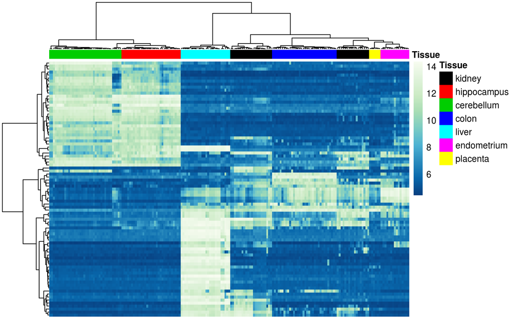

```r
## ===== Your code is finished  =============== ##
library(pheatmap)
library(RColorBrewer)

annotation_col = data.frame(
  Tissue = SE$Tissue
  )
rownames(annotation_col) = colnames(SE)

hmcol <- colorRampPalette(rev(brewer.pal(n = 9, name = "GnBu")))(100)
cols <- palette(brewer.pal(8, "Dark2"))[as.fumeric(as.character(unique(SE$Tissue)))]
names(cols) <- unique(SE$Tissue)

pheatmap(assay(SE)[idx,],
         color = hmcol,
         show_rownames=FALSE,
         show_colnames=FALSE,
         annotation_col=annotation_col,
         annotation_colors = list(Tissue = cols),
         scale = "none",
         clustering_method="ward.D2",
         clustering_distance_cols="euclidean")
```

- SAQ3: Based on the mutual information and heat map, can we use only 85 genes to better classify tissues? Try to explain why we can obtain the observed performance using less than 0.5% of the total genes?
- Answer: Yes, because the MI is around 2.44 which is larger than the value we obtained before. The heat map shows relative clear differences of samples among different tissues. Those 85 genes are selected to have higher variance among samples. Other genes with relative low variance will not contribute to the clustering of samples to different tissues. Also, those genes with relative low variance may have deleterious effect on the cluster efficiency. So we only use the most powerful features(genes) which is enough to cluster samples to different tissues.
- SAQ4: If we search exhaustively for all possible gene subsets, will we overestimate the above performance? Please provide your reasons. If the answer is yes, then what strategies can be used to solve this problem?
- Answer: Yes, maybe. If we search exhaustively for all possible gene subsets, the estimation process will be very complex. Thus, any gene could influence the estimation. This is bad because some genes have low variance which means they will have no or less contribution to the clustering. Those interferences could deleteriously effect the estimation accuracy.

## 4. Determine the Number of Gene Clusters

The quality of the cluster partitions can also be determined by the average Silhouette values of each cluster.

The silhouette values quantifies how similar the object is to its own cluster (cohesion) when compared to other clusters (separation). The range of the contour is -1 to +1, where a high value indicates that the object matches well with its own cluster, and poorly matches with neighboring clusters.

In the following steps, we need to calculate the Silhouette values of gene clustering. We will use the `pam()` function defined in the `cluster` package to perform this analysis. The function will run K-medoids clustering on the rows of the input matrix. Firstly, Set k = 2 so that we will have 2 gene clusterst. Please use the same 85 genes selected in the previous question. Save the output of `pam()` in the variable named `pamclu`.

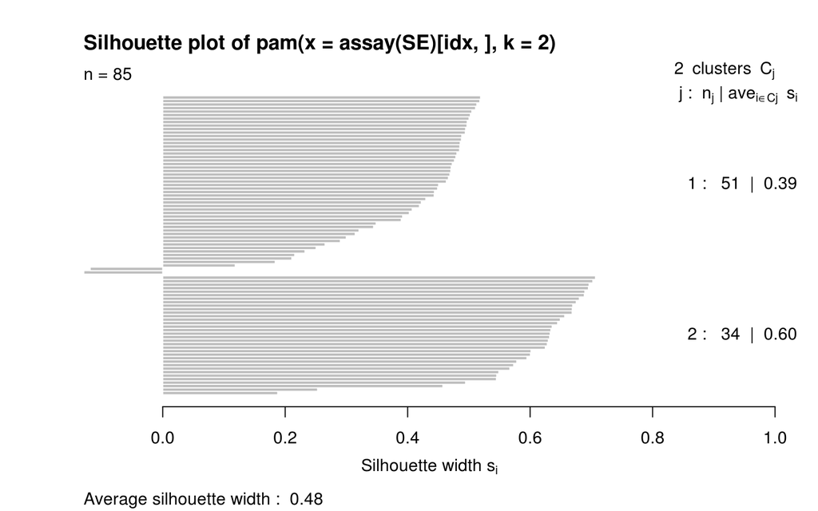

```r
set.seed(101)
## === Hint code, fill the "___"  ============= ##
#library(cluster)
#pamclu = pam(___, ___) #Set k = 2, make sure to subset with idx first!
## ===== Enter your code below  =============== ##
library(cluster)
pamclu = pam(assay(SE)[idx,], k=2) #Set k = 2, make sure to subset with idx first!
## ===== Your code is finished  =============== ##
plot(silhouette(pamclu), main=NULL)
```

Then, we will try to calculate the average silhouette values using different ks. Fill in the middle of the following code chunk block to calculate silhouette statistics for each k. Remember, we need a FOR loop to perform this process.

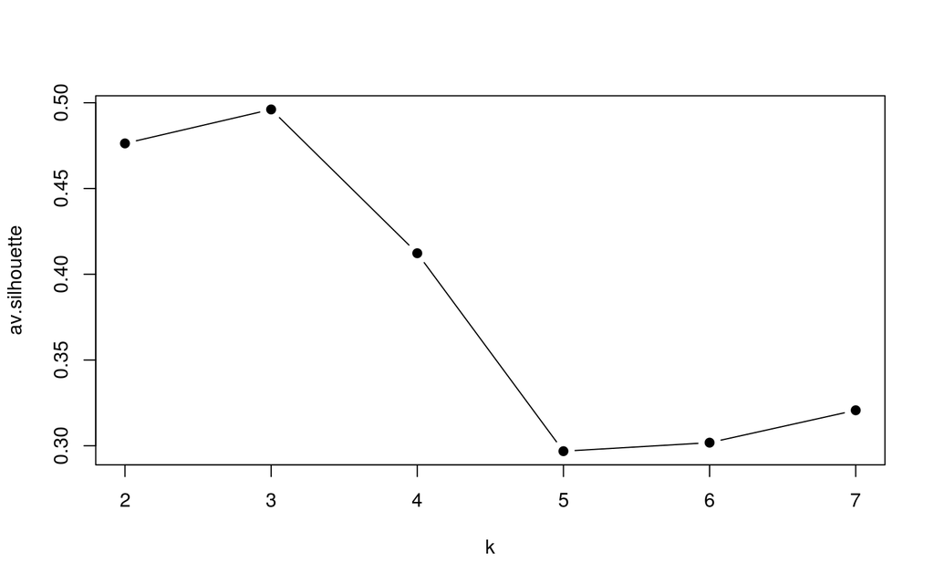

```r
## === Hint code, fill the "___"  ============= ##
#Ks = sapply(2:7, function(i) summary(silhouette(pam(___, ___)))$avg.width)
## ===== Enter your code below  =============== ##
Ks = sapply(2:7, function(i) summary(silhouette(pam(assay(SE)[idx,], k=i)))$avg.width)
## ===== Your code is finished  =============== ##
plot(2:7,Ks,xlab="k",ylab="av.silhouette",type="b",pch=19)
```

- SAQ5: When k = 2, is each gene well justified in its own cluster? In the ks we tested, what is the optimal number of gene modules? What is the most unlikely number? Please explain your reasons.
- Answer: No. It is optimal when k = 3. Because the average silhouette values is the highest when k = 3. This means that the object is well matched to its own cluster and poorly matched to neighboring clusters.

## 5. Functional Characterization of the Gene Modules.

```r
## === Hint code, fill the "___"  ============= ##
#d <- dist(___) #make sure to subset with idx first!
#hc <- hclust(___)
#genecluster <- cutree(___)
## ===== Enter your code below  =============== ##
d <- dist(assay(SE)[idx,]) #make sure to subset with idx first!
hc <- hclust(d)
genecluster <- cutree(hc, k =3)
## ===== Your code is finished  =============== ##
sapply(unique(genecluster), function(i) writeLines(names(genecluster)[genecluster == i], paste0("List_",i,".txt")) )
```

```r
writeLines(names(genecluster), "Background.txt")
```

After running the last 3 lines of code, you will get 3 sets of probe ids, which are saved under the project directory. Next, go to the [DAVID](https://david.ncifcrf.gov/) website.

Do the following steps:

1. Click Start Analysis >> Upload >> Copy & Paste genes in Background.txt >> select `Background` >> submit
2. Upload >> Copy & Paste genes in List_i.txt >> select `Gene List` >> Submit list
3. click List >> select List_i >> Use >> click Background >> select Background_1 >> Use
4. Clear all >> Pathways >> KEGG_PATHWAY
5. Functional annotation chart >> functional annotation chart
6. Repeat step 3, 4, and 5 for all the List_is

You can find the description for the functional enrichment results at [here](https://david.ncifcrf.gov/helps/functional_annotation.html#summary)

- SAQ6: Report the top 5 KEGG terms enriched in each cluster(if any). Then, explain what the columns “P-value” and “Benjamini” mean? How do we determine whether each term is statistically significant or not? Combining the heat map and tissue information, please try to provide some biological explanations for the enriched terms.
- Answer:

The top 5 KEGG terms enriched in the first cluster are: Complement and coagulation cascades, Platelet activation, Protein digestion and absorption, PPAR signaling pathway, ECM-receptor interaction. The top 5 KEGG terms enriched in the second cluster are: cAMP signaling pathway, Insulin secretion, HIF-1 signaling pathway, Dopaminergic synapse, Mineral absorption. There is no term in the third cluster.

The p-value is EASE Score, a modified Fisher Exact P-Value. Fisher Exact test is used to determine whether the proportions of those falling into each category differs by group. The smaller, the more enriched. Benjamini-Hochberg q-value is similar to a p-value corrected for multiple hypothesis testing using the false discovery rate. If the adjusted p-value is less than criteria (< 0.05 or < 0.01), this means that the term is statistically significant.

Complement and coagulation cascades and platelet activation are part of the acute response related to blood. These two terms take up about 1/3 of genes in the first cluster. Protein digestion and absorption happens in small intestine during digestion. PPAR signaling pathway can relate to the regulation of insulin-mediated uptake of glucose. These two terms take up about 1/5 of genes in the first cluster and they are about digestion and absorption. The remaining function is ECM-receptor interaction, which is important in tissue and organ morphogenesis regulating cellular activities.

cAMP signaling pathway, HIF-1 signaling pathway are about signaling transmission on cell membrane. HIF-1 signaling pathway is important in the body’s response to low oxygen concentrations or hypoxia. Insulin secretion happens on pancreatic islets. They are all about energy regulation of the body and these functions take up about 1/3 of the genes in the second cluster. Dopaminergic synapse is responsible for neurotransmission. Mineral absorption is about ion transport and homeostasis.

Generally, the genes are clustered into three groups according to the functions in tissues. The functions of genes in the first group is mainly about acute response related to blood and digestion and absorption. The functions of genes in the second group is mainly about energy (oxygen and suggar) regulation. The third group does not have any term. Those genes are from 7 different tissues. The result shows that genes from different tissues may have similar functions like the functions in clusters.